# R Notebook

## File metadata

Template author: Morgan Carr-Markell  
Template last modified on: March 21, 2023 Notebook modified by: Katie Wang  
Notebook last modified on: March 27, 2023

## Goals of the assignment

This homework assignment is meant to give you experience with:

- cleaning/wrangling data
- fitting linear models
- testing the assumptions of linear models
- dealing with spatial autocorrelation using mixed models
- interpreting coefficients of models with transformed data

It is based very loosely on this paper (but the data is slightly different and analyses here are far simpler):

Katelin D. Pearson, Natalie L. R. Love, Tadeo Ramirez-Parada, Susan J. Mazer, Jenn M. Yost (2021) “Phenological trends in the california poppy (eschscholzia californica): digitized herbarium specimens reveal intraspecific variation in the sensitivity of flowering date to climate change,” Madroño, 68(4), 343-359. https://doi.org/10.3120/0024-9637-68.4.343

The purpose of that study was to use the newly-finished California phenology project records to determine whether climate change has influenced the timing of flowering of a common native California species, California poppy (*Eschscholzia californica*). Many of the records you will analyze for this assignment are in the California Botanic Garden’s Herbarium.

## Data citations

Biodiversity occurrence data published by: CCH2 Portal (accessed through the CCH2 Portal Portal, https://www.cch2.org/portal, 2023-03-17).

PRISM Climate Group, Oregon State University, https://prism.oregonstate.edu, data created 13 Jun 2021, accessed 14 Mar 2023.

## Loading libraries

```r
library(tidyverse) # for wrangling data
library(sf) # for creating/plotting sf points
library(maps) # for mapping
library(ape) # for testing whether there is spatial autocorrelation
library(regclass) # for testing for multicollinearity
library(spaMM) # for mixed models with spatial autocorrelation included
library(RSpectra) # for faster model fitting
```

## Reading in data

The csv file called occurrences is from the [CCH2 herbarium database portal](https://www.cch2.org/portal/). It includes only records of California poppy (*Eschscholzia californica*) that were collected in California and flowering when they were collected. This allows us to use the time of collection to analyze flower phenology (=timing of life history events).

The csv files with mean temperature (degrees C) and annual precipitation totals (mm) were both generated using raster files from [PRISM](https://prism.oregonstate.edu/historical/), which we talked about on Monday in the spatial interpolation lecture slides. There is an R package called [prism](https://cran.r-project.org/web/packages/prism/prism.pdf) that allows you to download many raster files from the PRISM online database, but it takes a long time and the files are quite large because they cover the whole world in 4 km x 4 km grid squares. So for the purposes of this homework assignment I did the downloading and first processing steps for you, creating ~70MB csv files that each contain the bounds of the grid squares just for California, the centroids of the grid squares (x and y), and columns of values for each year from 1920 to 2020. These data are not in a tidy format, they are in a wide format, which makes the file sizes smaller and easier to share. However, that does mean that extracting the values you will need for each plant record will take a few minutes.

```r
CA_poppy <- read.csv("data/CA_poppy_occurrences.csv")
tmean <- read.csv("data/California_grid_tmean_1920_2020.csv")
ppt <- read.csv("data/California_grid_ppt_1920_2020.csv")
```

## Processing the occurrence records

First, take a look at the CA_poppy records:

```r
glimpse(CA_poppy)
```

```
Rows: 1,450
Columns: 97
$ id                             <int> 183064, 183086, 183087, 183088, 183089, 183090, 183091, 183092, 183093, 183094, 183095, 18309…
$ institutionCode                <chr> "OBI", "OBI", "OBI", "OBI", "OBI", "OBI", "OBI", "OBI", "OBI", "OBI", "OBI", "OBI", "OBI", "O…
$ collectionCode                 <chr> "", "", "", "", "", "", "", "", "", "", "", "", "", "", "", "", "", "", "", "", "", "", "", "…
$ ownerInstitutionCode           <lgl> NA, NA, NA, NA, NA, NA, NA, NA, NA, NA, NA, NA, NA, NA, NA, NA, NA, NA, NA, NA, NA, NA, NA, N…
$ basisOfRecord                  <chr> "PreservedSpecimen", "PreservedSpecimen", "PreservedSpecimen", "PreservedSpecimen", "Preserve…
$ occurrenceID                   <chr> "6f5b279d-6663-41ef-b88c-465cd19413bc", "0822eea3-2cc7-491b-8949-8f7388ebd00a", "95b3f50d-21b…
$ catalogNumber                  <chr> "OBI103899", "OBI103932", "OBI103834", "OBI103885", "OBI103882", "OBI103926", "OBI103901", "O…
$ otherCatalogNumbers            <chr> "55251", "11804", "11808", "22956", "71232", "53587", "57674", "57972", "58253", "4995", "301…
$ higherClassification           <chr> "Organism|Plantae|Viridiplantae|Streptophyta|Embryophyta|Tracheophyta|Spermatophytina|Magnoli…
$ kingdom                        <chr> "Plantae", "Plantae", "Plantae", "Plantae", "Plantae", "Plantae", "Plantae", "Plantae", "Plan…
$ phylum                         <chr> "Tracheophyta", "Tracheophyta", "Tracheophyta", "Tracheophyta", "Tracheophyta", "Tracheophyta…
$ class                          <chr> "Magnoliopsida", "Magnoliopsida", "Magnoliopsida", "Magnoliopsida", "Magnoliopsida", "Magnoli…
$ order                          <chr> "Ranunculales", "Ranunculales", "Ranunculales", "Ranunculales", "Ranunculales", "Ranunculales…
```

[output cut: 84 more lines]

You’ll notice that there are many columns about IDs, taxonomy, who collected the specimen, what specific collection it is part of, who entered the data into the database, etc.

### Data wrangling

For the purposes of this analysis, we’re going to include year, mean annual temperature, and total annual precipitation as independent variables in our models. Temperature and precipitation values will come from the tmean and ppt data frames, but we’ll need year from the CA_poppy data frame. Our dependent variable will be the day of the year that the flowering plant was collected (startDayOfYear). Finally, we will need to match plant specimens to temperature and precipitation at specific sites, and there may be spatial autocorrelation that we need to control for in our models. Therefore, we will need the coordinates of each observation (decimalLongitude and decimalLatitude).

1. First, overwrite CA_poppy and select only:
- year
- decimalLongitude
- decimalLatitude
- startDayOfYear

**Note:** You’ll need to use dplyr::select instead of just select because multiple libraries we loaded have functions named ‘select’ in them.

```r
CA_poppy <- CA_poppy %>%
  dplyr::select(year, decimalLongitude, decimalLatitude, startDayOfYear)
```

Next, we’ll need to deal with the fact that multiple plants may have been collected at exactly the same site in the same year. One way to do this is to group by year, decimal Longitude, and decimalLatitude and then summarize across those groups to get the mean startDayOfYear for each.

```r
CA_poppy <- CA_poppy %>%
  group_by(year, decimalLatitude, decimalLongitude) %>%
  summarize(startDayOfYear = mean(startDayOfYear))
```

2. Then, use filter() get rid of rows we won’t be able to use in our model, including rows where:
- startDayOfYear is NA (Note: I’d recommend using !is.na(startDayOfYear))
- year < 1920
- year > 2020

```r
CA_poppy <- CA_poppy %>%
  filter(!is.na(startDayOfYear)) %>%
  filter(year >= 1920) %>%
  filter(year <= 2020)
```

### Removing outliers

Next, let’s look to see if we should remove any data due to extreme (and probably erroneous) coordinates or flowering dates.

We’ll start by getting an outline of California from the R maps package to help us plot coordinates and decide whether they are reasonable:

```r
USA_sf <- st_as_sf(maps::map("state",
                             fill=TRUE,
                             plot =FALSE),
                   crs = 4326) # WGS84

CA_sf <- USA_sf %>%
  filter(ID == "california")
```

Now let’s create an sf version of the CA_poppy data frame:

```r
CA_poppy_sf <- st_as_sf(CA_poppy,
                        coords = c("decimalLongitude", "decimalLatitude"),
                        crs = 4326) # WGS84
```

Now we can plot the points:

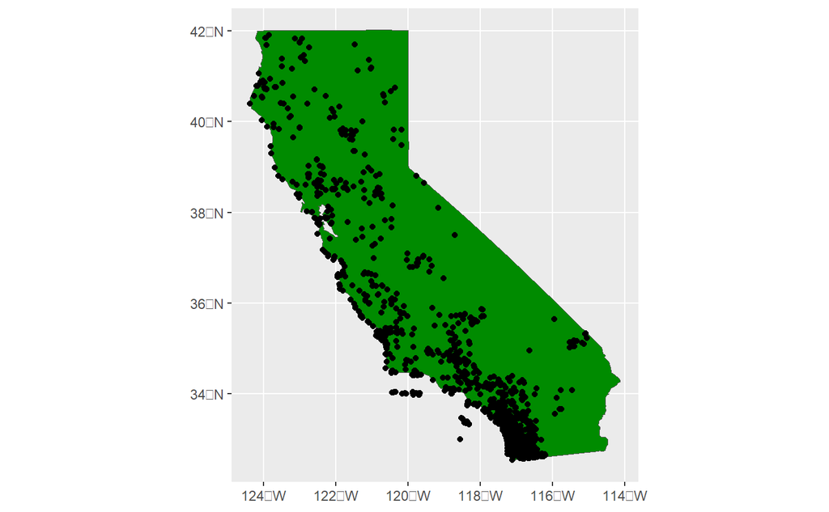

```r
CA_poppy_sf %>%
  ggplot() +
  geom_sf(data = CA_sf, fill = "green4") +
  geom_sf()
```

```r
CA_poppy_sf <- CA_poppy_sf %>%
  st_crop(c(xmin = -130, ymin = 32, xmax = 110, ymax = 50))
```

Don’t worry if you get an error message here about attribute variables.

Redraw the map to check your work:

[figure not shown]

```r
CA_poppy_sf %>%
  ggplot() +
  geom_sf(data = CA_sf, fill = "green4") +
  geom_sf()
```

6. Next, look at the range of startDayOfYear using a box plot or histogram:

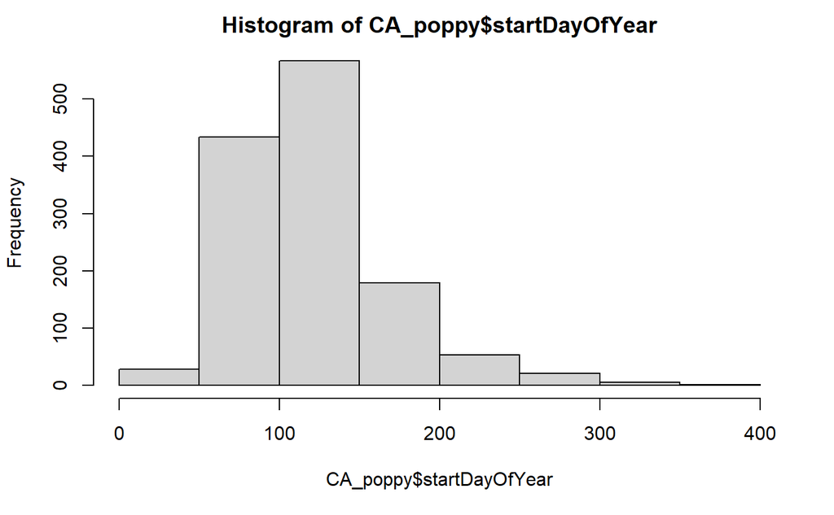

```r
hist(CA_poppy$startDayOfYear)
```

This distribution is difficult to judge, but there aren’t very clear large gaps in the data. Without more knowledge of the life history of this species, I would keep all of these points.

## Extracting environmental variables

The function I wrote below is not the most efficient function, but it will allow us to extract the associated temperature and precipitation values from the tmean and ppt data frames for each row of our CA_poppy data frame.

```r
find_climate_var <- function(year, longitude, latitude, climate_df){
  # to match the correct year column
  lookup_column <- paste0("year_", as.character(year))

  # filter to get the correct spatial grid square
  climate_df <- climate_df %>%
    filter(xmin < longitude & xmax > longitude & ymin < latitude & ymax > latitude)

  # if there is an associated grid square
  if (nrow(climate_df) > 0){
    # extract the climate value
    value <- climate_df[1, lookup_column]
  } else {
    # otherwise, set the cell to NA
    value <- NA
  }

  return(value)
}
```

Now we can use the mapply function to apply the find_climate_var function and get temperature (mean degrees Centigrade) and then precipitation values (total annual precipitation in millimeters). This will take several minutes so I would recommend running the chunk below, and while it is running, go to these [online directions](https://drive.google.com/file/d/1Oh4wiVjroHBoo-GNL890MPeTdegyVFov/view?usp=share_link) I made to download data from CCH2 for the independent part of the homework.

```r
CA_poppy$tmean <- mapply(find_climate_var,
                         CA_poppy$year,
                         CA_poppy$decimalLongitude,
                         CA_poppy$decimalLatitude,
                         MoreArgs = list(climate_df = tmean))

CA_poppy$ppt <- mapply(find_climate_var,
                       CA_poppy$year,
                       CA_poppy$decimalLongitude,
                       CA_poppy$decimalLatitude,
                       MoreArgs = list(climate_df = ppt))

# Write out results so we can reload them later if need be
write.csv(CA_poppy, "CA_occurrences_w_climate_data.csv", row.names = F)
```

Once that is done, we can use filter to get rid of any rows with NAs for tmean and ppt:

```r
CA_poppy <- CA_poppy %>%
  filter(!is.na(tmean)) %>%
  filter(!is.na(ppt))
```

## Multivariate linear model without accounting for distance

### Removing distances of zero

If there is significant spatial autocorrelation, we will need to control for it in our model. Unfortunately, Moran’s I and linear mixed models with a spatial correlation structure both assume that no data points come from exactly the same coordinates (distance between them is zero). That means that to test for spatial autocorrelation, we need to change our data so that no two records were collected in precisely the same place. The easiest way to do this is to group by coordinates and then randomly select one record to keep using the sample_n() function:

```r
CA_poppy_separate <- CA_poppy %>%
  group_by(decimalLongitude, decimalLatitude) %>%
  sample_n(1)
```

### Fitting a linear model

We are interested in three things:

- First, is there a significant trend in flower phenology over time?
- Second, is there a significant trend in the climate variables over time?
- Third, are either of the climate variables good predictors of flower phenology in this species?

That means we want examine 4 different models. The last model that includes year, tmean, and ppt is the most interesting, so we’ll also examine that model for fit and spatial autocorrelation.

#### phenology_year_model:

```r
phenology_year_model <- lm(startDayOfYear ~ year, data = CA_poppy_separate)

summary(phenology_year_model)
```

```
Call:
lm(formula = startDayOfYear ~ year, data = CA_poppy_separate)

Residuals:
     Min       1Q   Median       3Q      Max
-106.325  -30.041   -6.497   19.181  224.109

Coefficients:
             Estimate Std. Error t value Pr(>|t|)
(Intercept) 611.05808   99.61870   6.134 1.14e-09 ***
year         -0.24688    0.05009  -4.929 9.36e-07 ***
---
Signif. codes:  0 ‘***’ 0.001 ‘**’ 0.01 ‘*’ 0.05 ‘.’ 0.1 ‘ ’ 1

Residual standard error: 45.49 on 1271 degrees of freedom
Multiple R-squared:  0.01876,   Adjusted R-squared:  0.01798
F-statistic: 24.29 on 1 and 1271 DF,  p-value: 9.362e-07
```

There appears to be a trend in flower phenology over time.

#### tmean_year_model

1. Use the same syntax and lm() function to fit a model with tmean as the dependent variable, year as the independent variable, and CA_poppy_separate as the data source. Then use the summary function to examine the model output:

```r
tmean_year_model <- lm(tmean ~ year, data = CA_poppy_separate)

summary(tmean_year_model)
```

```
Call:
lm(formula = tmean ~ year, data = CA_poppy_separate)

Residuals:
     Min       1Q   Median       3Q      Max
-12.2614  -1.2592   0.3445   1.6117   7.2853

Coefficients:
             Estimate Std. Error t value Pr(>|t|)
(Intercept) -28.36885    4.85223  -5.847 6.37e-09 ***
year          0.02209    0.00244   9.054  < 2e-16 ***
---
Signif. codes:  0 ‘***’ 0.001 ‘**’ 0.01 ‘*’ 0.05 ‘.’ 0.1 ‘ ’ 1

Residual standard error: 2.216 on 1271 degrees of freedom
Multiple R-squared:  0.06059,   Adjusted R-squared:  0.05985
F-statistic: 81.98 on 1 and 1271 DF,  p-value: < 2.2e-16
```

2. Does there seem to be a significant trend in temperature over the years? If so, is temperature increasing or decreasing?  
   There is a significant trend in temperature (p < 2e-16). The temperature is increasing every year, as 0.02209 is a positive slope.

#### ppt_year_model

3. Use the same syntax and lm() function to fit a model with ppt (precipitation) as the dependent variable, year as the independent variable, and CA_poppy_separate as the data source. Then use the summary function to examine the model output:

```r
ppt_year_model <- lm(ppt ~ year, data = CA_poppy_separate)

summary(ppt_year_model)
```

```
Call:
lm(formula = ppt ~ year, data = CA_poppy_separate)

Residuals:
    Min      1Q  Median      3Q     Max
-509.71 -232.65 -100.07   98.47 2472.64

Coefficients:
             Estimate Std. Error t value Pr(>|t|)
(Intercept) 3418.8566   821.8202   4.160 3.39e-05 ***
year          -1.4683     0.4132  -3.553 0.000394 ***
---
Signif. codes:  0 ‘***’ 0.001 ‘**’ 0.01 ‘*’ 0.05 ‘.’ 0.1 ‘ ’ 1

Residual standard error: 375.3 on 1271 degrees of freedom
Multiple R-squared:  0.009837,  Adjusted R-squared:  0.009058
F-statistic: 12.63 on 1 and 1271 DF,  p-value: 0.0003942
```

4. Does there seem to be a significant trend in total annual precipitation over the years? If so, is it increasing or decreasing?  
   There is a significant trend in total annual precipitation (p = 0.000394 < 0.05). Precipitation is decreasing every year, as -1.4683 is a negative slope.

#### phenology_climate_model

5. Now fit a linear model with startDayOfYear as the dependent variable, year, tmean (mean temperature), ppt (total precipitation) as the independent variables, and CA_poppy_separate as the data source. Then use the summary function to examine the model output:

```r
phenology_climate_model <- lm(startDayOfYear ~ year + tmean + ppt, data = CA_poppy_separate)

summary(phenology_climate_model)
```

```
Call:
lm(formula = startDayOfYear ~ year + tmean + ppt, data = CA_poppy_separate)

Residuals:
    Min      1Q  Median      3Q     Max
-96.192 -26.546  -5.036  19.384 223.861

Coefficients:
              Estimate Std. Error t value Pr(>|t|)
(Intercept) 361.047096  92.385995   3.908  9.8e-05 ***
year         -0.065668   0.047217  -1.391 0.164541
tmean        -7.454149   0.570215 -13.073  < 2e-16 ***
ppt           0.011274   0.003367   3.349 0.000835 ***
---
Signif. codes:  0 ‘***’ 0.001 ‘**’ 0.01 ‘*’ 0.05 ‘.’ 0.1 ‘ ’ 1

Residual standard error: 41.56 on 1269 degrees of freedom
Multiple R-squared:  0.1821,    Adjusted R-squared:  0.1802
F-statistic:  94.2 on 3 and 1269 DF,  p-value: < 2.2e-16
```

##### Assumption: Linear relationship

We can make 3 scatter plots to see if a linear relationship seems reasonable.

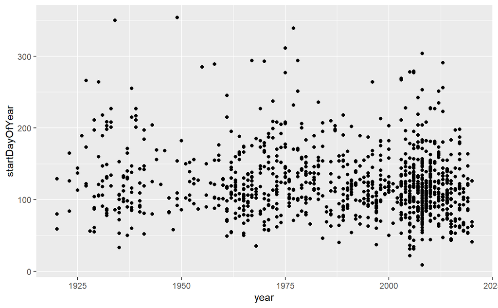

```r
CA_poppy_separate %>%
  ggplot(aes(x = year, y = startDayOfYear)) +
  geom_point()
```

A linear relationship between these variables seems reasonable.

6. Make scatter plots of tmean vs. startDayOfYear and then ppt vs. startDayOfYear to assess those relationships. Unless the relationships very clearly follow a non-linear relationship (exponential, logistic, etc.) we generally decide that assuming a linear relationship is reasonable.

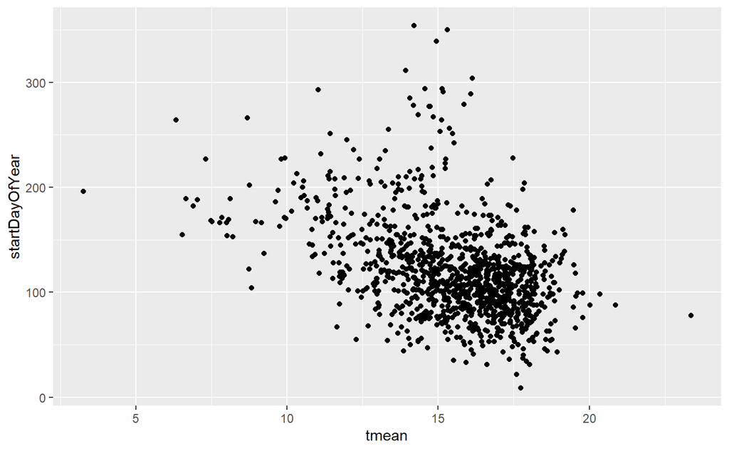

```r
CA_poppy_separate %>%
  ggplot(aes(x = tmean, y = startDayOfYear)) +
  geom_point()
```

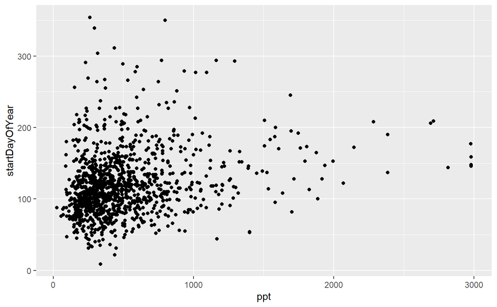

```r
CA_poppy_separate %>%
  ggplot(aes(x = ppt, y = startDayOfYear)) +
  geom_point()
```

##### Assumption: Homoscedasticity/Homogeneity of variances

Now let’s look at the residuals:

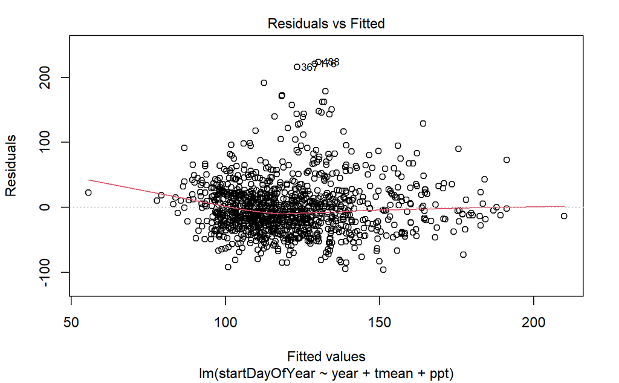

```r
plot(phenology_climate_model, 1)
```

The variance seems to be distributed fairly uniformly for all fitted values. Fewer values at the two extremes mean we would expect some decrease in variation there.

##### Assumption: Normally-distrubuted residuals

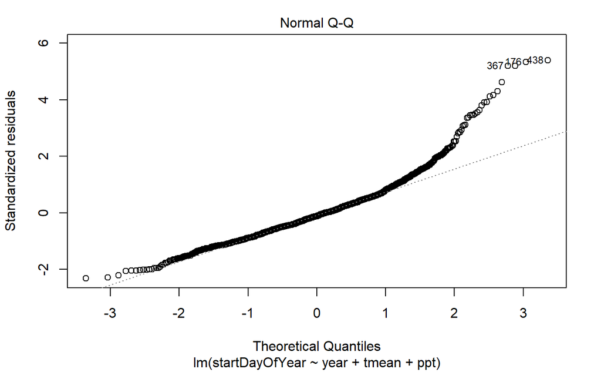

```r
plot(phenology_climate_model, 2)
```

That deviation from the y = x line suggests that a transformation could be helpful. Let’s see if a log transformation helps:

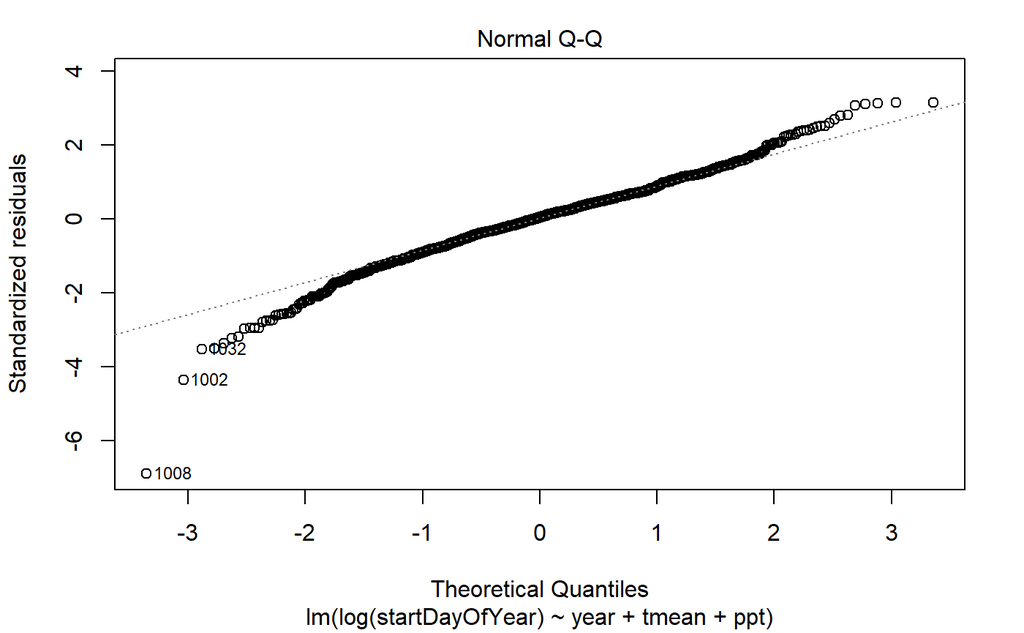

```r
phenology_climate_model <- lm(log(startDayOfYear) ~ year + tmean + ppt, data = CA_poppy_separate)

plot(phenology_climate_model, 2)
```

That’s not perfect, but it’s a big improvement and our sample size will help us deal with some deviation from normality.